# Homework 10

Vince Trost

October 25, 2016

*Source file* ⇒ HW_10.Rmd

##### Problems 12.1, 12.2, 15.1(skip Armistice Day) and 15.2(copy/paste this for d: “£100” )

### Problem 12.1

For each sex, find the 5 most popular names in `BabyNames` adding up over all the years.

```r
BabyNames %>%
  group_by(sex, name) %>%
  summarise(total = sum(count)) %>%
  filter(rank(desc(total)) <= 5)
```

```
## Source: local data frame [10 x 3]
## Groups: sex [2]
##
##      sex      name   total
##    <chr>     <chr>   <int>
## 1      F Elizabeth 1591439
## 2      F  Jennifer 1461186
## 3      F     Linda 1450328
## 4      F      Mary 4112464
## 5      F  Patricia 1570135
## 6      M     James 5091189
## 7      M      John 5073958
## 8      M   Michael 4293460
## 9      M    Robert 4789776
## 10     M   William 4038447
```

### Problem 12.2

Using `BabyNames`, for each year, find the fraction of all babies born in that year who were given the name in the top 100 for that year. Make a graph showing how this fraction has changed over the years.  
The first challenge in this for me is that to `group_by(year)`, the year column cannot be of type `int`. So I had to change it to a type of `Factor` so it had levels to group on.

```r
MyBabyNames <- BabyNames %>%
  mutate(year2 = as.factor(year))
#don't need the extra column now...
MyBabyNames <- MyBabyNames %>%
  select(name, sex, count, year2)
#rename it as regular 'year'
names(MyBabyNames)[4] <- "year"
str(MyBabyNames)
```

```
## 'data.frame':    1792091 obs. of  4 variables:
##  $ name : chr  "Mary" "Anna" "Emma" "Elizabeth" ...
##  $ sex  : chr  "F" "F" "F" "F" ...
##  $ count: int  7065 2604 2003 1939 1746 1578 1472 1414 1320 1288 ...
##  $ year : Factor w/ 134 levels "1880","1881",..: 1 1 1 1 1 1 1 1 1 1 ...
```

Now `MyBabyNames` is in the format I want. Now I need to know how many babies were born in each year. The simple thing to do here would be do a `group_by(year) %>% summarise(totalBabies = sum(count))` but that didn’t work, so after searching StackOverflow I found [this](https://stackoverflow.com/questions/1660124/how-to-sum-a-variable-by-group) solution…

```r
TotalBabiesByYear <- aggregate(MyBabyNames$count, by=list(MyBabyNames$year), FUN=sum)
names(TotalBabiesByYear)[1] <- "year"
names(TotalBabiesByYear)[2] <- "numBabies"
head(TotalBabiesByYear, 5)
```

```
##   year numBabies
## 1 1880    201484
## 2 1881    192700
## 3 1882    221537
## 4 1883    216952
## 5 1884    243468
```

This worked. This will help us in calculating the fraction in the top 100. Now I can make a table of the top 100 names per year.

```r
PopularNamesByYear <- BabyNames %>%
  group_by(year, name) %>%
  summarise(total = sum(count)) %>%
  filter(rank(desc(total)) <= 100)
head(PopularNamesByYear, 5)
```

```
## Source: local data frame [5 x 3]
## Groups: year [1]
##
##    year   name total
##   <int>  <chr> <int>
## 1  1880    Ada   652
## 2  1880  Agnes   473
## 3  1880 Albert  1493
## 4  1880 Alfred   469
## 5  1880  Alice  1414
```

Great. Now we have the number of occurrences for the top 100 names in each year. If we can `group_by` and `summarise` those by year to get the total amount of names in the top 100, we’ll be golden.

```r
PopularNamesTotals <- PopularNamesByYear %>%
  group_by(year) %>%
  summarise(totals = sum(total))
head(PopularNamesTotals, 5)
```

```
## # A tibble: 5 × 2
##    year totals
##   <int>  <int>
## 1  1880 132817
## 2  1881 126360
## 3  1882 144279
## 4  1883 141032
## 5  1884 155498
```

Figures, the simple way works now. I spent a lot of time working on this and after I restarted my R session, things seemed to work logically again. Much time wasted, but hey I’m here now.  
Alright let’s calculate that fraction of names in the top 100 and make this graph!!!!  
First roadblock- can’t join on years because one is of type `int` and the other is of type `factor`. Let’s change the `factor` one back to `int`.

```r
str(PopularNamesTotals)
```

```
## Classes 'tbl_df', 'tbl' and 'data.frame':    134 obs. of  2 variables:
##  $ year  : int  1880 1881 1882 1883 1884 1885 1886 1887 1888 1889 ...
##  $ totals: int  132817 126360 144279 141032 155498 153544 161733 155699 187341 180016 ...
```

```r
str(TotalBabiesByYear)
```

```
## 'data.frame':    134 obs. of  2 variables:
##  $ year     : Factor w/ 134 levels "1880","1881",..: 1 2 3 4 5 6 7 8 9 10 ...
##  $ numBabies: int  201484 192700 221537 216952 243468 240856 255320 247396 299481 288952 ...
```

We can see our `factor` type is in `TotalBabiesByYear`. Let’s fix that.

```r
TotalBabiesByYear$year <- as.numeric(levels(TotalBabiesByYear$year))[TotalBabiesByYear$year]
str(TotalBabiesByYear)
```

```
## 'data.frame':    134 obs. of  2 variables:
##  $ year     : num  1880 1881 1882 1883 1884 ...
##  $ numBabies: int  201484 192700 221537 216952 243468 240856 255320 247396 299481 288952 ...
```

The StackOverflow question used to complete this can be referenced [here](https://stackoverflow.com/questions/3418128/how-to-convert-a-factor-to-an-integer-numeric-without-a-loss-of-information). Now the join works perfectly.

```r
FractionTable <- TotalBabiesByYear %>%
  left_join(PopularNamesTotals, by = c('year' = 'year'))
head(FractionTable, 5)
```

```
##   year numBabies totals
## 1 1880    201484 132817
## 2 1881    192700 126360
## 3 1882    221537 144279
## 4 1883    216952 141032
## 5 1884    243468 155498
```

So `numBabies` is our TOTAL number of babies named that year. The column `totals` is our top 100 named babies. Let’s calculate the fraction and plot that graph.

```r
FractionTable <- FractionTable %>%
  mutate(frac_in_top_100 = (totals/numBabies))
head(FractionTable, 5)
```

```
##   year numBabies totals frac_in_top_100
## 1 1880    201484 132817       0.6591938
## 2 1881    192700 126360       0.6557343
## 3 1882    221537 144279       0.6512637
## 4 1883    216952 141032       0.6500608
## 5 1884    243468 155498       0.6386794
```

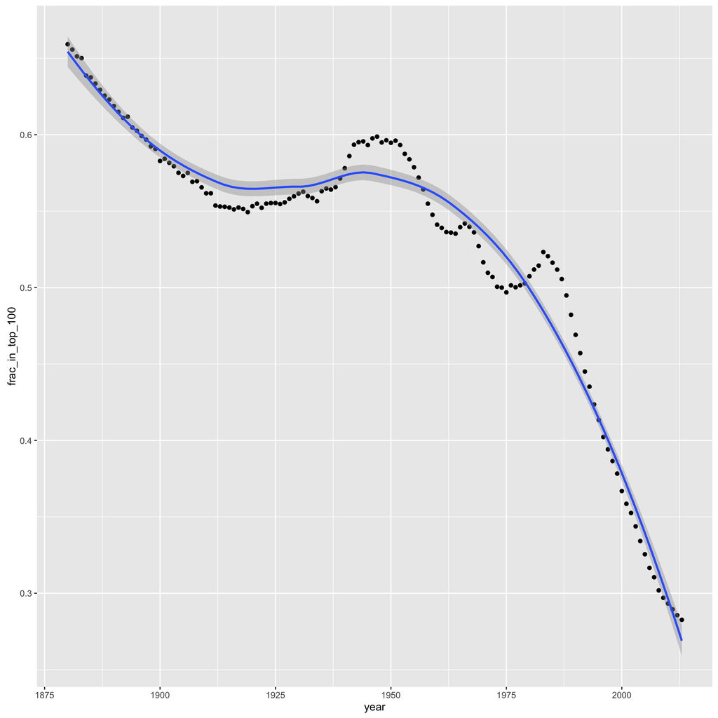

```r
ggplot(data=FractionTable,aes(x=year,y=frac_in_top_100))+geom_point() + stat_smooth(method=loess)
```

Interesting! As time goes on, people are way less likely to name their child a ‘top 100’ name. I guess as time went on and diversity was valued more, so were unique names! Awesome.

### Problem 15.1

For each date, choose an appropriate function from the `lubridate` package to translate the character string.

- mdy(“April 30, 1777”)
- mdy(“06-23-1912”)
- dmy(“3 March 1847”)
- mdy(“July 20, 1969”)

```r
library(lubridate)
#my birthday- Valentines Day '96
bday <- mdy("02/14/1996")
bday
```

```
## [1] "1996-02-14"
```

```r
johann <- mdy("April 30, 1777")
bday-johann
```

```
## Time difference of 79912 days
```

```r
alan <- mdy("06-23-1912")
bday-alan
```

```
## Time difference of 30551 days
```

```r
alex <- dmy("3 March 1847")
bday-alex
```

```
## Time difference of 54404 days
```

```r
moon <- mdy("July 20, 1969")
bday-moon
```

```
## Time difference of 9705 days
```

### Problem 15.2

For which ones does `as.numeric()` work correctly? How about `tidyr::extract_numeric()`?

```r
#a.
as.numeric("42,659.30")
```

```
## [1] NA
```

```r
tidyr::extract_numeric("42,659.30") #winner
```

```
## extract_numeric() is deprecated: please use readr::parse_numeric() instead
```

```
## [1] 42659.3
```

```r
#b.
as.numeric("17%")
```

```
## [1] NA
```

```r
tidyr::extract_numeric("17%") #winner
```

```
## extract_numeric() is deprecated: please use readr::parse_numeric() instead
```

```
## [1] 17
```

```r
#c.
as.numeric("Nineteen")
```

```
## [1] NA
```

```r
tidyr::extract_numeric("Nineteen")
```

```
## extract_numeric() is deprecated: please use readr::parse_numeric() instead
```

```
## [1] NA
```

```r
#neither!
#d.
as.numeric('£100')
```

```
## [1] NA
```

```r
tidyr::extract_numeric('£100') #winner
```

```
## extract_numeric() is deprecated: please use readr::parse_numeric() instead
```

```
## [1] 100
```

```r
#e.
as.numeric('9.8 m/seconds-square')
```

```
## [1] NA
```

```r
tidyr::extract_numeric('9.8 m/seconds-square')
```

```
## extract_numeric() is deprecated: please use readr::parse_numeric() instead
```

```
## [1] NA
```

```r
#neither
#f.
as.numeric('9.8 m/s^2')
```

```
## [1] NA
```

```r
tidyr::extract_numeric('9.8 m/s^2') #not correct but rendered it
```

```
## extract_numeric() is deprecated: please use readr::parse_numeric() instead
```

```
## [1] 9.82
```

```r
#g.
as.numeric('6.62606957 x 10^-34 m2 kg / s')
```

```
## [1] NA
```

```r
tidyr::extract_numeric('6.62606957 x 10^-34 m2 kg / s')
```

```
## extract_numeric() is deprecated: please use readr::parse_numeric() instead
```

```
## [1] NA
```

```r
#neither
#h.
as.numeric('6.62606957e-34') #winner
```

```
## [1] 6.62607e-34
```

```r
tidyr::extract_numeric('6.62606957e-34')
```

```
## extract_numeric() is deprecated: please use readr::parse_numeric() instead
```

```
## [1] NA
```

```r
#i.
as.numeric('42.659,30')
```

```
## [1] NA
```

```r
tidyr::extract_numeric('42.659,30') #winner
```

```
## extract_numeric() is deprecated: please use readr::parse_numeric() instead
```

```
## [1] 42.6593
```